# PSTAT126: Part 2 Simple Linear Model

Chris Park, Justin McCarthy, James San, Shengnan Liu

2023-06-02

## Introduction: Recap of Variables

The data set included 13 variables in which 6 were categorical and 7 were quantitative.In our first Simple Linear Model we chose response variable as EJECTION FRACTION and SERUM SODIUM as the predictor.

The reason we chose ejection fraction as the response variable was due to the fact that this quantitative metric is a great proxy for heart failure. The ejection fraction by definition is how much blood the heart can pump relative to how much blood the heart can hold in the left ventricle. Moreover, the reason we chose serum sodium was due to stereotypical dietary fads that claim over-consumption of sodium is the reason for certain health issues.

## Hypotheses Testing

Our null hypothesis is that beta1 is less than 0 while the alternative hypothesis is that beta1 is greater than 0.
$$H_0 :\beta_1 < 0$$
$$H_A:\beta_1 > 0$$

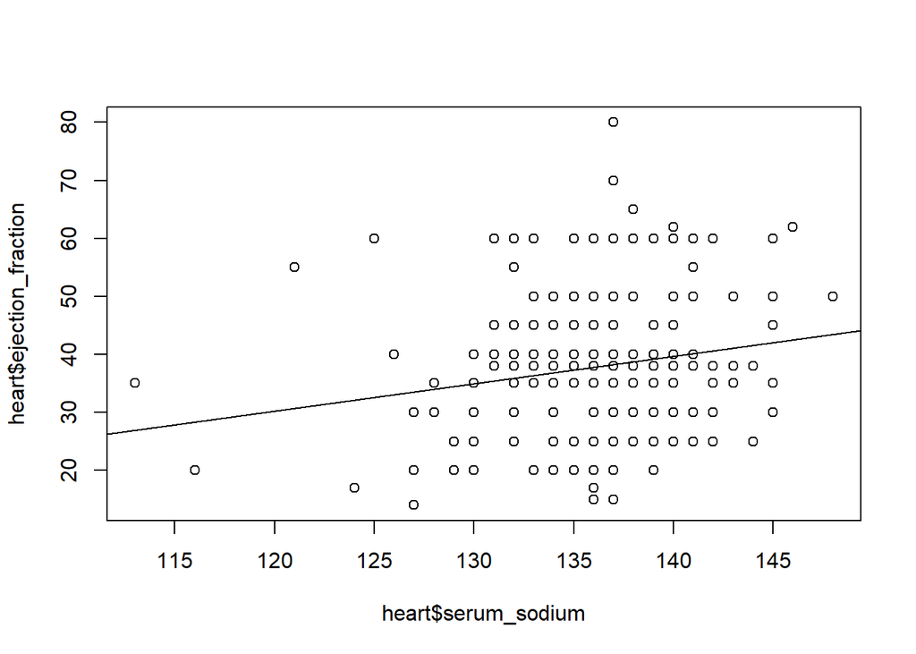

Simple Linear Model: plot

```r
#Simple Linear Model: Create and Plot
heart <- read.csv("heart_failure_clinical_records_dataset.csv")
plot(heart$serum_sodium, heart$ejection_fraction)
serum_sodium_lm <- lm(heart$ejection_fraction ~ heart$serum_sodium)
abline(serum_sodium_lm)
```

```r
serum_sodium_lm
```

```
##
## Call:
## lm(formula = heart$ejection_fraction ~ heart$serum_sodium)
##
## Coefficients:
##        (Intercept)  heart$serum_sodium
##           -26.3753              0.4718
```

$$Y = \beta_1x_1 + \beta_0$$
$$Y = 0.471x_1 - 26.37$$
Our linear model shows that 𝛽zero (the intercept) has a value of -26.3753 and𝛽one (the slope) is 0.4718. Log and square root transformations were performed on the simple linear model, however, it only brought about a very minimal decrease to the p-value and minimal increase to the R-squared. Therefore we concluded that a transformation was unnecessary.